# ゲームハード週販レポート (2025.11.23)

国内ゲームハード週販レポート (2025-11-23)

- ハードウェアの販売データはファミ通の調査結果を基にしています。
- 一部のデータは処理上の都合により、週次値に調整しています。
- 過去の週販レポート

## 直近4週間のハード売り上げ／累計推移

Switch2の販売台数は先週の10万台からさらに増加の12万台。エアライダーに合わせてのスパイク的な大量出荷は 無かったようですが出荷台数増で年末商戦が加速しています。300万台まであと13万台、 さらに出荷増があれば来週到達の可能性があります。

Switchも伸びています。理由はわからないのですが、これが年末商戦というものでしょうか。 (プレゼント需要なら一月先ですからね)

### PS5値下げ & ブラックフライデーで大躍進

PS5はDE日本語版の値下げと強力なブラックフライデーセール(12/1迄)効果により約37,000台、先週比630%と大幅増加です。 これだけの週販は3月9日以来です。

販売台数を牽引したのはPS5DE日本語版です。 先週の489台から48倍の23381台。一方通常版PS5は2235台ですから、完全に日本での売れ筋が切り替わりました。 PS5 DE日本語版の施策は効果があったと考えていいでしょう。

PS5Proも大きく伸ばしました。2057台から11367台と5倍増です。 ブラックフライデー 15000円OFFが効果的でした。 セールは12/1までなので、次回、次々回集計も期待できます。

PS5DE日本語は購入行動を変える効果があることは判明しました。 成功と言えるかどうかは、セール後の売り上げ推移を待つことになります。 それでも、このペースなら2020年の最低記録を更新することは無いでしょう。一安心ですね。

| 集計日 | ハード | 販売台数 | 累計台数 |
| --- | --- | --- | --- |
| 2025-11-02 | Nintendo Switch2 | 83,825 | 2,551,846 |
|  | Nintendo Switch | 26,708 | 36,151,232 |
|  | PlayStation5 | 7,537 | 7,129,204 |
|  | Xbox Series X\|S | 309 | 687,077 |
|  | PlayStation4 | 18 | 9,490,926 |
| 2025-11-09 | Nintendo Switch2 | 90,410 | 2,642,256 |
|  | Nintendo Switch | 23,877 | 36,175,109 |
|  | PlayStation5 | 7,691 | 7,136,895 |
|  | Xbox Series X\|S | 487 | 687,564 |
|  | PlayStation4 | 16 | 9,490,942 |
| 2025-11-16 | Nintendo Switch2 | 101,549 | 2,743,805 |
|  | Nintendo Switch | 22,736 | 36,197,845 |
|  | PlayStation5 | 5,855 | 7,142,750 |
|  | Xbox Series X\|S | 574 | 688,138 |
|  | PlayStation4 | 15 | 9,490,957 |
| 2025-11-23 | Nintendo Switch2 | 126,953 | 2,870,758 |
|  | PlayStation5 | 36,983 | 7,179,733 |
|  | Nintendo Switch | 29,370 | 36,227,215 |
|  | Xbox Series X\|S | 349 | 688,487 |
|  | PlayStation4 | 17 | 9,490,974 |

現時点の年間PS販売台数 761,741台、2020年の記録797,797台を超えるまで、あと36,057台

## 2025年の週販推移

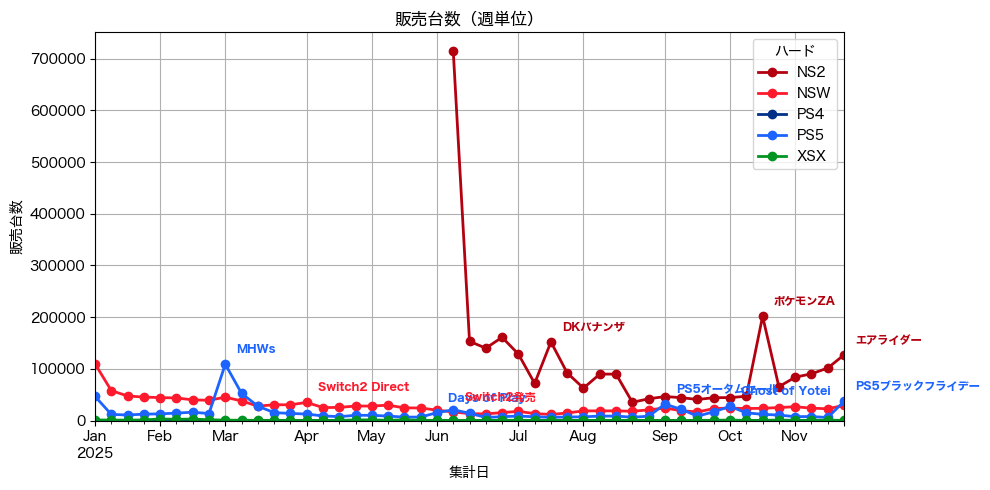

### 2025年の週販推移(拡大）

Switch2の年末商戦出荷が順調に伸びています。このまま年末まで増え続け15万ラインで推移すると入手し易くなると思います。

PS5の売り上げがSwitchを超えました。セールに売れるPS5は健在です。 セール後のダウンがどの程度の値で留まるか、興味深い状況です。

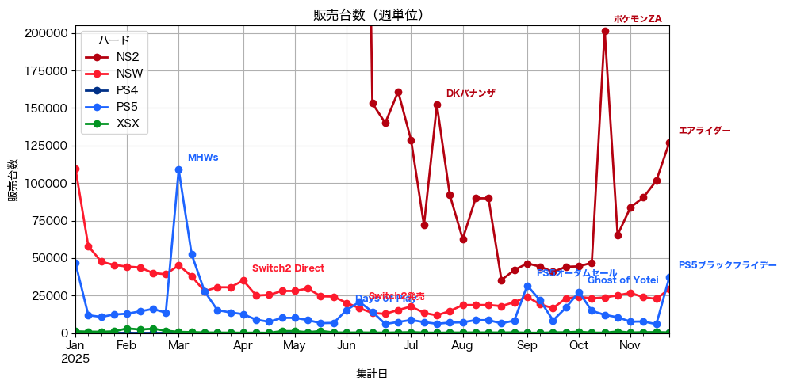

## 2025年の月間販売推移

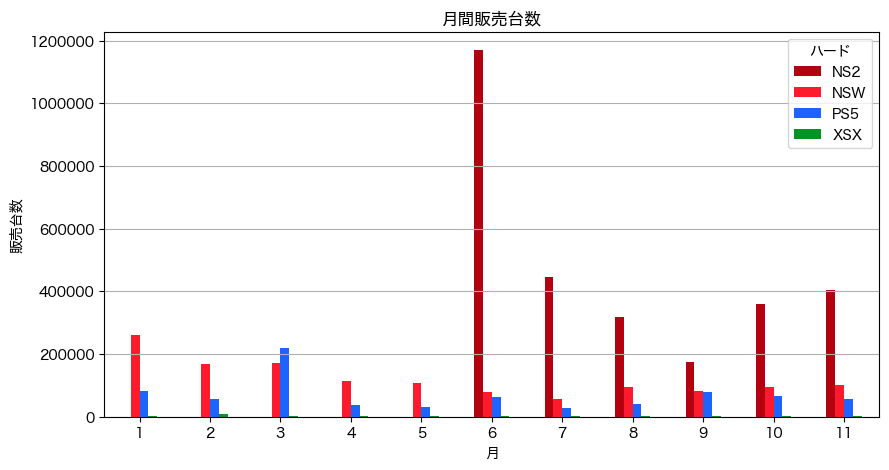

Switch2の11月販売台数が40万台を超えました。7月の44万台を超えるのも確実です。 Switchも10月販売台数を超えました、さすがの年末商戦です。

PS5は次回集計でも月間でSwitchを上回るのは困難でしょう。

| hw month | NS2 | NSW | PS5 | XSX |
| --- | --- | --- | --- | --- |
| 1 | 0 | 260,447 | 81,587 | 3,861 |
| 2 | 0 | 167,188 | 56,886 | 9,751 |
| 3 | 0 | 171,921 | 218,300 | 2,081 |
| 4 | 0 | 113,513 | 38,983 | 1,710 |
| 5 | 0 | 106,506 | 32,001 | 3,467 |
| 6 | 1,169,684 | 78,097 | 63,516 | 1,400 |
| 7 | 444,706 | 57,532 | 28,959 | 1,197 |
| 8 | 319,690 | 94,517 | 39,004 | 1,599 |
| 9 | 175,542 | 82,946 | 78,693 | 1,121 |
| 10 | 358,399 | 96,080 | 64,732 | 2,253 |
| 11 | 402,737 | 102,691 | 58,066 | 1,719 |

### Nintendo Switchの月間販売台数： 2023,2024年との比較

Switch2大量出荷にも関わらずSwitchの販売台数は安定しています。 11月の前年比も10月と同程度に落ち着きそうです。

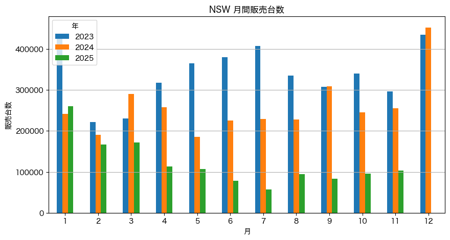

### PlayStation 5の月間販売台数： 2023, 2024年との比較

値下げとセール効果が顕著ですが、11月の前年比は7割程度に収まるでしょう。月間10万台はギリギリ無理そうです。

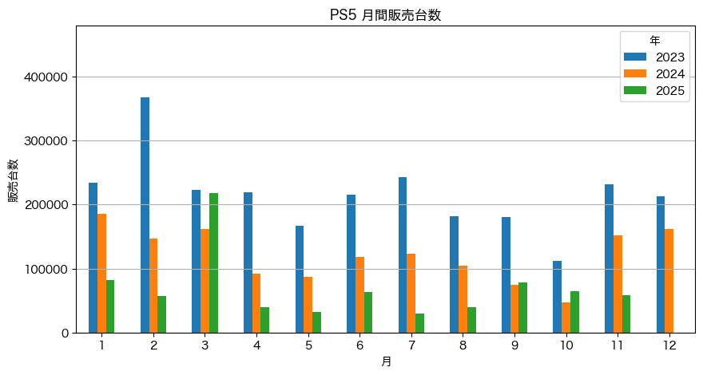

## 累計販売推移

Switchの累計3600万台が多過ぎて、Switchに合わせたスケールだと他機種の状況が全然わからないですね。

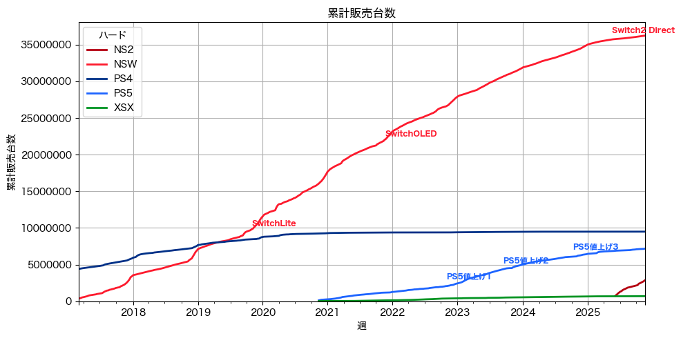

### 累計販売台数差

#### Switch vs PS4 & Switch2 vs PS5

Switch2とPS5の累計差が430万台となり、SwitchとPS4の初期累計差436万台を下回りました。

Switch/PS4はここから2年で追いついたわけですが、 追うSwitch2のペースがどこまで上がるか、逃げるPS5が値下げ効果でどこまで台数を増やせるか、 この先の推移はまだまだ未知数です。

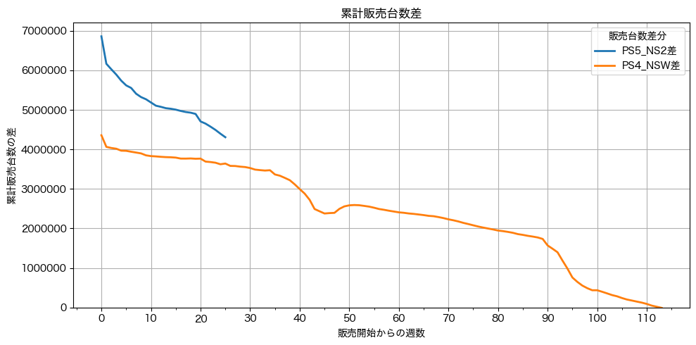

### PS5 vs PS4 累計推移比較

PS5DE日本語版とブラックフライデー効果でわずかにPS5が上向きましたが、 まだまだPS4に追いつくペースには遠い状況です。

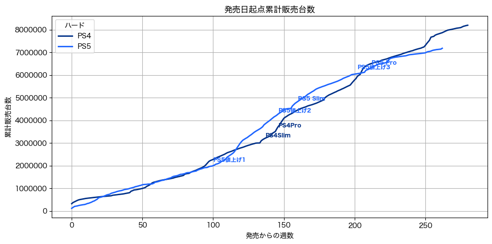

## Switch2初動状況

Switch2の累計グラフの傾きが年末商戦で上昇しつつあります。 春とは言わず、年内にGBAをキャッチアップできる可能性が出てきました。

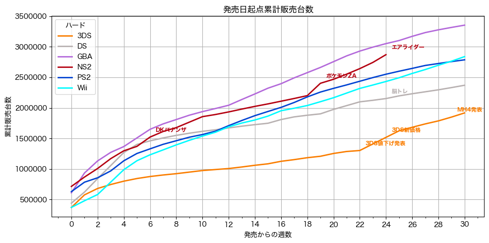

| ハード | 週数 | 販売数 |
| --- | --- | --- |
| GBA | 24 | 3,051,291 |
| NS2 | 24 | 2,870,758 |
| PS2 | 24 | 2,550,771 |
| Wii | 24 | 2,431,810 |
| DS | 24 | 2,152,728 |
| 3DS | 24 | 1,517,625 |

## 年単位の状況

全機種合わせた年毎のハード販売の状況です。

2025年の販売台数が499万台に到達。来週には500万台突破は確実です。 最終的に年内600万台は無理そうですが、570万台は超えてきそうです。

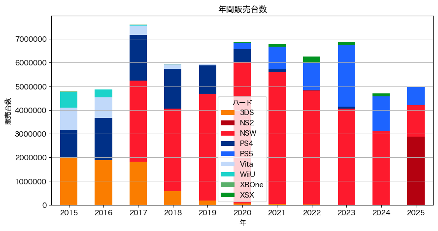

### 年単位のメーカーシェア

2025年 年末商戦でさらなる任天堂シェア上昇が予想されますが、PS5 DE値下げとブラックフライデーセールの効果でどこまで抑えられるか。

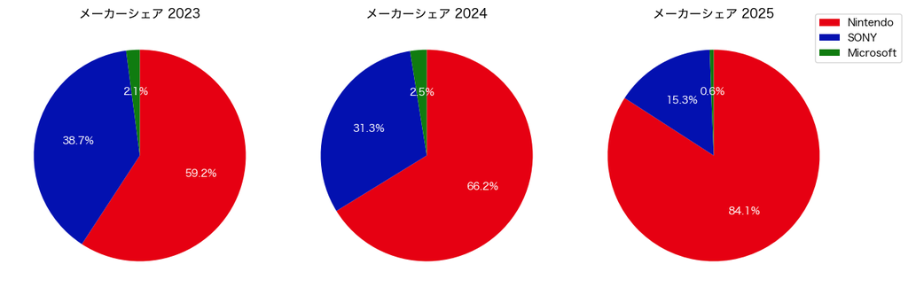